# PCFL: Week 12 wrap-up

### Last week’s games

| Away | Away points | Home | Home points |
| --- | --- | --- | --- |
| Captain Clairvoyant | 175.34 | The G.O.A.T. | 114.30 |
| Middle Earth Hangry Hobbits | 124.62 | First Timers The FTs | 104.18 |
| Pigskin on the Gridiron | 105.90 | Southern Sharks | 78.90 |
| Athens Team Sasquatch | 128.58 | KC Gophers | 151.84 |
| Georgia Peanuts | 150.34 | Jumpin’ Jaheims | 76.98 |

Bye weeks are over, but the NFL is having plenty of COVID issues. So as always, keep an eye on your players and on the schedule.

#### Best performing players

Here’s last week’s **10 best performing players.**

| Player | Points | Team |
| --- | --- | --- |
| Tyreek Hill | 53.40 | KC Gophers |
| Derrick Henry | 37.50 | Captain Clairvoyant |
| Antonio Gibson | 34.10 | Middle Earth Hangry Hobbits |
| Deshaun Watson | 33.12 | Middle Earth Hangry Hobbits |
| Will Fuller V | 33.10 | The G.O.A.T. |
| Patrick Mahomes | 31.28 | First Timers The FTs |
| A.J. Brown | 26.90 | KC Gophers |
| Aaron Rodgers | 25.64 | Captain Clairvoyant |
| Nick Chubb | 25.10 | Captain Clairvoyant |
| James Robinson | 24.40 | Georgia Peanuts |

Unsuprisingly, the high team scores were the result of some high scoring players. Tyreek Hill had a monster week receiving for the Chiefs, which benefited Christine’s Gophers. The Hobbits also had a couple of players over 30 (Gibson at RB and Watson at QB).

#### Best addition and worst starters

There were 8 players added last week. Which was the **best new addition**?

| Date added | Name | Points | Team |
| --- | --- | --- | --- |
| 2020-11-29 | Ryan Fitzpatrick | 19.28 | Athens Team Sasquatch |
| 2020-12-03 | Matt Ryan | 13.90 | Southern Sharks |
| 2020-11-29 | Tyler Bass | 11.00 | Pigskin on the Gridiron |
| 2020-11-28 | Zack Moss | 7.80 | Southern Sharks |
| 2020-11-29 | Jordan Wilkins | 7.20 | Jumpin’ Jaheims |
| 2020-12-03 | James Conner | 0.00 | Georgia Peanuts |
| 2020-12-03 | Salvon Ahmed | 0.00 | Georgia Peanuts |
| 2020-12-03 | Myles Gaskin | 0.00 | Southern Sharks |

We’re getting to the point of the season where finding value on the waiver wire is getting difficult. Ryan Fitzpatrick had a decent week as a QB, but otherwise, not a lot of big scoring to be had. Barring injury, teams look to be largely locked in at this point.

Who won the **best scoring bench** award last week?

| Team | Points |
| --- | --- |
| Jumpin’ Jaheims | 96.78 |
| KC Gophers | 82.45 |
| Middle Earth Hangry Hobbits | 80.99 |
| Pigskin on the Gridiron | 69.65 |
| Georgia Peanuts | 60.22 |
| The G.O.A.T. | 50.62 |
| Southern Sharks | 49.30 |
| Captain Clairvoyant | 48.40 |
| First Timers The FTs | 33.30 |
| Athens Team Sasquatch | 32.21 |

Evan, Christine, and Scott all had plenty of points in reserve this week.

### League standings and season stats

Here’s a look at our current standings

| Team | Division | W | L | Points scored | Points allowed | Points rank | Playoff rank |
| --- | --- | --- | --- | --- | --- | --- | --- |
| Georgia Peanuts | Hot Dish | 9 | 3 | 1569.30 | 1264.94 | 1 | 1 |
| Captain Clairvoyant | Grits | 9 | 3 | 1454.91 | 1289.56 | 2 | 2 |
| Athens Team Sasquatch | Grits | 8 | 4 | 1356.28 | 1326.48 | 3 | 3 |
| The G.O.A.T. | Grits | 7 | 5 | 1306.19 | 1408.80 | 6 | 4 |
| KC Gophers | Hot Dish | 6 | 6 | 1309.04 | 1327.73 | 5 | 5 |
| Southern Sharks | Hot Dish | 5 | 7 | 1257.76 | 1282.67 | 8 | 6 |
| Pigskin on the Gridiron | Grits | 5 | 7 | 1249.30 | 1354.60 | 9 | 7 |
| Middle Earth Hangry Hobbits | Hot Dish | 4 | 8 | 1341.14 | 1364.45 | 4 | 8 |
| First Timers The FTs | Hot Dish | 4 | 8 | 1297.00 | 1361.68 | 7 | 9 |
| Jumpin’ Jaheims | Grits | 3 | 9 | 1213.48 | 1373.49 | 10 | 10 |

Here’s our current awards leaders from these standings:

- Yellow shirt (most points): Georgia Peanuts
- D-FENCE (least points allowed): Georgia Peanuts (*new*)
- Tough luck (points rank - playoff rank): Hobbits (4th in points and 8th in the standings)
- Lucky ducks (playoff rank - points rank): The GOAT, Sharks, and Pigskin on the Gridiron are all tied here.

Here’s a list of the **top five scoring performances** so far this season.

| Team | Week | Points scored | Result |
| --- | --- | --- | --- |
| Georgia Peanuts | 8 | 183.82 | W |
| Captain Clairvoyant | 12 | 175.34 | W |
| First Timers The FTs | 2 | 171.28 | W |
| Georgia Peanuts | 7 | 163.68 | W |
| Georgia Peanuts | 9 | 152.14 | W |

As he probably knew beforehand, Brian guided Captain Clairvoyant to a dominant performance this week, the second highest point total of the season.

Lastly, here’s a look at the **points trendline** for each team.

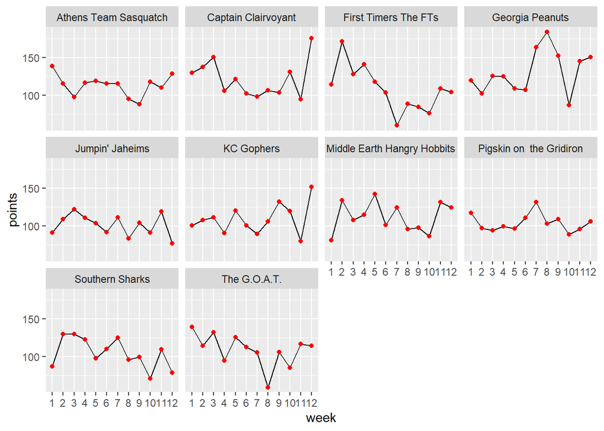

### Playoff picture

Just two weeks left before we start the playoffs, and the field is becoming clear. Brian and I are in. I’ve won the Hot Dish division. Brian could still lose the Grits title to Robbie with a couple of losses and end up as a wild card. If Robbie loses out (he’s up against Scott this week and me next week), he could end up tied with Jacob or Christine, and then points scored would be the tie breaker. But he’s currently up by 50 points there, so it’s likely he would get a spot that way.

The real fight is for that last wild card spot. Jacob’s one game ahead of Christine for that right now, but they have a pivotal matchup this week. If Christine wins that, she’d move into the lead based on a tied record and more points scored.

Sadly, everyone else has been eliminated at this point. Back when we lived in Iowa, the wrestling program there talked about ending the season on an odd number (e.g., spot 5 rather than 6), which means you went out a winner. Given that we have two weeks of consolation rounds, there’s still something to play for.

## Next week’s games

Here’s a quick summary of next week’s matchups:

| week | away_team | away_points | home_team | home_points | range |
| --- | --- | --- | --- | --- | --- |
| 13 | Pigskin on the Gridiron | 1249.30 | First Timers The FTs | 1297.00 | 47.70 |
| 13 | KC Gophers | 1309.04 | The G.O.A.T. | 1306.19 | 2.85 |
| 13 | Captain Clairvoyant | 1454.91 | Georgia Peanuts | 1569.30 | 114.39 |
| 13 | Athens Team Sasquatch | 1356.28 | Middle Earth Hangry Hobbits | 1341.14 | 15.14 |
| 13 | Southern Sharks | 1257.76 | Jumpin’ Jaheims | 1213.48 | 44.28 |

All eyes will be on the GOAT/Gophers matchup this week for the clear playoff implications. Brian and I are also playing in a battle of top seeds, though this is just a warmup for a potential title face-off at this point. In other matchups, it’s Richard vs. Erin/Trav, Robbie vs. Scott (which also has playoff implications), and Sarah vs. Evan. Good luck all!